# Basic R Analysis Guide for EPSY 5261

## Graphing data

### Dotplots and Histograms

To produce a dotplot, you will used the dotPlot() function. (Remember R is case-sensitive, so note the capital “P” in this function.) Run the following code chunk:

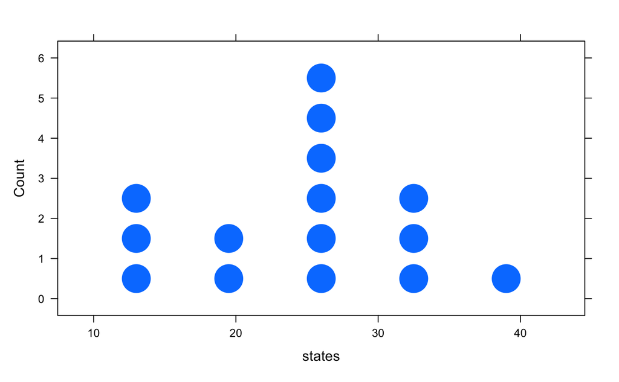

```r
dotPlot(~ states, data = travels)
```

A dotplot should appear in the graph window. Note that `dotPlot` is our goal, `states` is our x, and `travels` is our dataset.

To create a histogram of states, we could type the following syntax in a code chunk and then click Run.

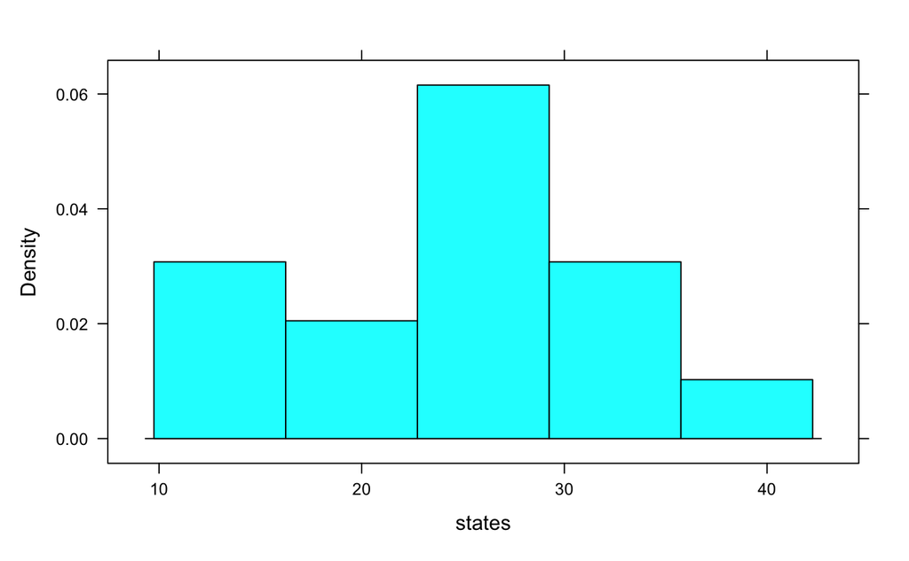

```r
histogram(~ states, data = travels)
```

A histogram will be displayed once you execute the above command. We can add on some options to help us view this data more clearly, like set the bin width (`width`), the title (`main`), and the x-axis title (`xlab`):

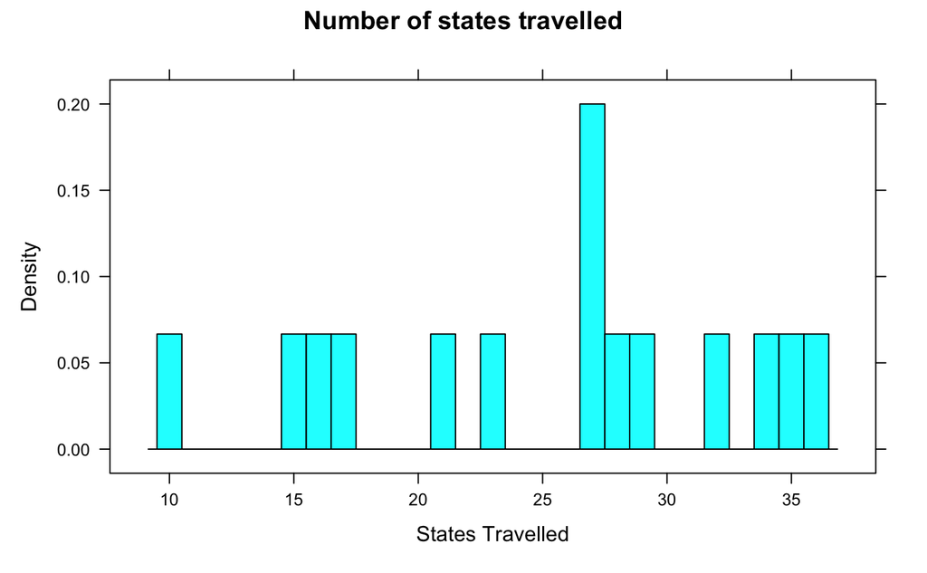

```r
histogram(~ states, data = travels,
          width = 1, # the width of each bar is now set to 1 as opposed to the wider bars in the last plot
          main = "Number of states travelled", # the main title of the plot
          xlab = "States Travelled") # title (or label) for the x-axis
```

What if we wanted to compare histograms of two variables? `histogram()` makes this easy – we have two *x* variables so we just put a plus sign between them since we want to see what happens for both variables. `outer = TRUE` tells R that we want to plot two different panels.

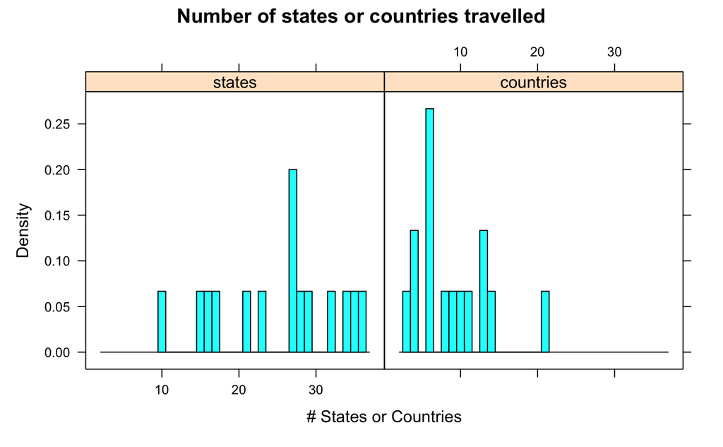

```r
histogram(~ states + countries, data = travels, width = 1,
          main = "Number of states or countries travelled",
          xlab = "# States or Countries", outer = TRUE)
```

## Boxplots

Using the same states/countries example above, we can make side-by-side boxplots. We gathered information about two variables, and both variables are measured in the same units. This allows us to easily compare the two variables in terms of features like shape, center, and variability.

We’ll be using the function `bwplot()` (i.e. *b*ox-and-*w*hiskers *plot*), which works the same way as the other functions we’ve used so far:

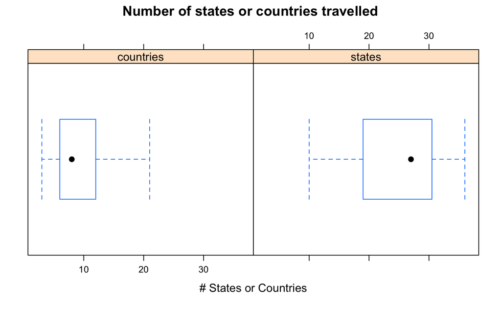

```r
bwplot(~ countries + states, data = travels, main = "Number of states or countries travelled",
       xlab = "# States or Countries", outer = TRUE)
```

We can tell `bwplot()` how to stack the panels vertically by using the `layout` argument. We give `layout` two numbers: the first is the number of columns, and the second is the number of rows; here we want 1 column, with 2 rows to put the plots on top of each other so we can compare:

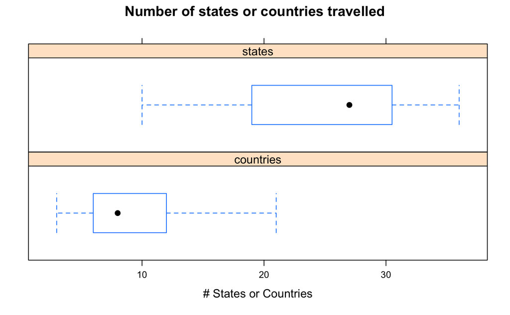

```r
bwplot(~ countries + states, data = travels, main = "Number of states or countries travelled",
       xlab = "# States or Countries", outer = TRUE, layout = c(1, 2))
```

## Descriptive Statistics

### Summarizing data with numbers

In addition to graphing data, we will often want to summarize our data numerically by computing various measures of center (like the mean and median) and variability (like the standard deviation, range, and interquartile range). This can be done by typing each summary function out on different lines of code but we do not have to do these computations individually.

```r
## Median of states variable
median(~ states, data = travels)
```

```
[1] 27
```

```r
## Standard deviation of states variable
sd(~ states, data = travels)
```

```
[1] 7.918032
```

## Comparing 2 groups on a quantitative variable

Any of the above functions can be calculated *by group* as well, where the group is another variable. Recall that in the `example` dataset, we have variables `gender` and `height`. So, we can just look at height by gender by using the formula `~ height | gender`. The term `|` can be read as “by”, and the term after the `|` is the grouping variable that we want to examine our data by. We need to remove missing values, since we know that `height` is missing some values.

```r
mean(~ height | gender, data = example_data, na.rm = TRUE)
```

```
    Male   Female
70.88889 65.36500
```

This will work with any of the other commands, such as `sd()`:

```r
sd(~ height | gender, data = example_data, na.rm = TRUE)
```

```
    Male   Female
3.233808 2.514458
```

Instead of listing each statistic separately, we can create separate summaries of several statistics, one for each group with the `favstats` command.

| gender | min | Q1 | median | Q3 | max | mean | sd | n | missing |
| --- | --- | --- | --- | --- | --- | --- | --- | --- | --- |
| Male | 63 | 68.5 | 71 | 72.75 | 78 | 70.88889 | 3.233808 | 18 | 0 |
| Female | 60 | 64.0 | 65 | 67.00 | 73 | 65.36500 | 2.514458 | 100 | 1 |

We can also create plots by a grouping variable in the same way. Here is a histogram of the heights by group:

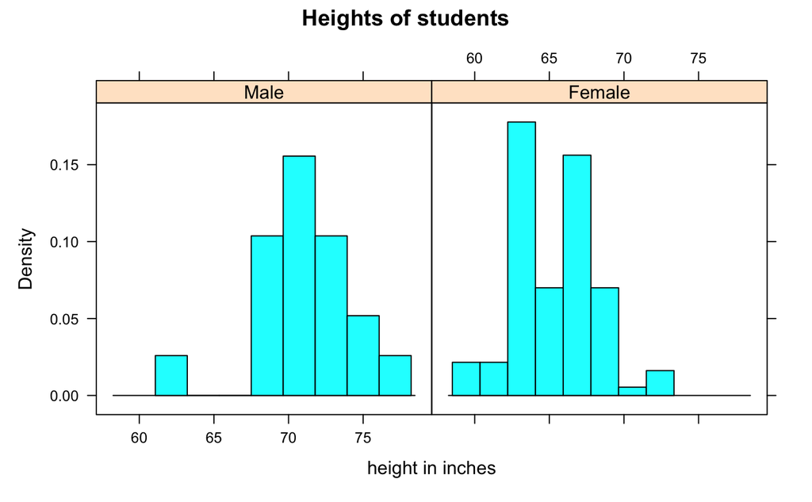

We also can compare the distributions more easily if we stack the plots vertically using the `layout` command introduced earlier:

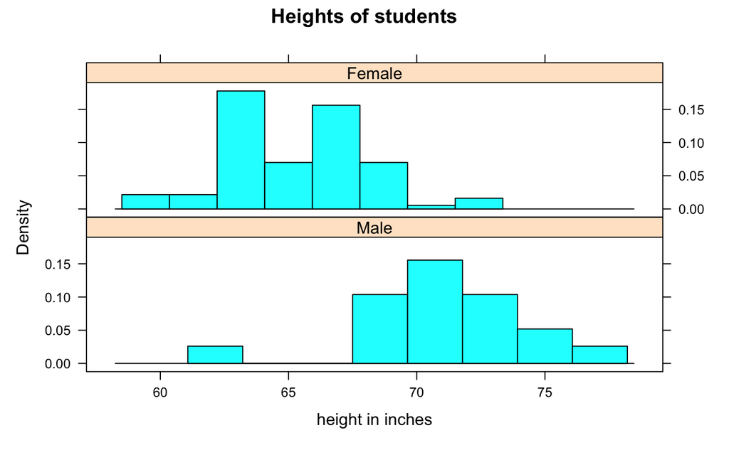